# Visualisation with Package grid

Last updated on 2016-12-12

Ning Yilin

[top] [[Back to index]](https://github.com/nyilin/My-R-help-sheets)

# Basic `grid`

This session shows what we can do with the `grid` package alone. We use built-in dataset `mtcars` for illustration.

```r
library(grid)
data("mtcars")
mtcars[, c("vs", "am", "gear", "carb")] <-
  lapply(mtcars[, c("vs", "am", "gear", "carb")], as.factor)
summary(mtcars)
```

```
##       mpg             cyl             disp             hp
##  Min.   :10.40   Min.   :4.000   Min.   : 71.1   Min.   : 52.0
##  1st Qu.:15.43   1st Qu.:4.000   1st Qu.:120.8   1st Qu.: 96.5
##  Median :19.20   Median :6.000   Median :196.3   Median :123.0
##  Mean   :20.09   Mean   :6.188   Mean   :230.7   Mean   :146.7
##  3rd Qu.:22.80   3rd Qu.:8.000   3rd Qu.:326.0   3rd Qu.:180.0
##  Max.   :33.90   Max.   :8.000   Max.   :472.0   Max.   :335.0
##       drat             wt             qsec       vs     am     gear
##  Min.   :2.760   Min.   :1.513   Min.   :14.50   0:18   0:19   3:15
##  1st Qu.:3.080   1st Qu.:2.581   1st Qu.:16.89   1:14   1:13   4:12
##  Median :3.695   Median :3.325   Median :17.71                 5: 5
##  Mean   :3.597   Mean   :3.217   Mean   :17.85
##  3rd Qu.:3.920   3rd Qu.:3.610   3rd Qu.:18.90
##  Max.   :4.930   Max.   :5.424   Max.   :22.90
##  carb
##  1: 7
##  2:10
##  3: 3
##  4:10
##  6: 1
##  8: 1
```

## Page Setup

Think of a new graph as a piece of paper. By default, the bottom left corner of the paper is assigned coordinate (0, 0) and the top right corner (1, 1), and you are free to draw anywhere on the paper by specifying the position relative to the default coordinates. No margin is preserved in this case, unless you choose not to draw anything beyond certain boundary.

In many cases, however, you do wish to leave certain margin in your plot so that it is easier to arrange your titles and axes. Furthermore, you may also want to adjust the coordinate system in the plotting region according to your data. This is easily done by pushing viewports on your current drawing region.

### Margins and Coordinates

Margins on each side of a page [bottom, left, top, right] is specified in terms of number of lines. Margins default to be c(5.1, 4.1, 4.1, 2.1), same as in par(mar).

The default coordinate of the current viewport is always (0, 1). This can be changed by specifying the scale of x and y coordinates when pushing a viewport.

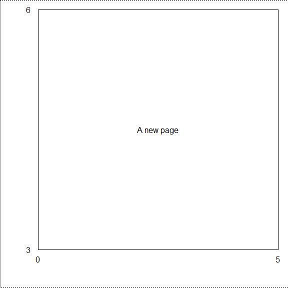

```r
grid.rect(gp = gpar(lty = 3))
pushViewport(plotViewport(c(4, 4, 1, 1), xscale = c(0, 5), yscale = c(3, 6)))
grid.rect()
grid.text("A new page")
grid.text(label = c(0, 5), x = unit(c(0, 5), "native"),
          y = unit(c(-1, -1), "lines"))
grid.text(label = c(3, 6), x = unit(c(-1, -1), "lines"),
          y = unit(c(3, 6), "native"))
popViewport()
```

### Subpannels

A page can be divided into several penals.

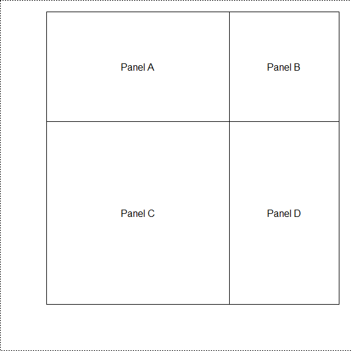

```r
grid.rect(gp = gpar(lty = 3))
pushViewport(plotViewport(c(4, 4, 1, 1)))
pushViewport(viewport(layout = grid.layout(nrow = 2, ncol = 2,
                                           widths = c(5, 3),
                                           heights = c(3, 5))))
pushViewport(viewport(layout.pos.row = 1, layout.pos.col = 1))
grid.rect()
grid.text("Panel A")
popViewport()
pushViewport(viewport(layout.pos.row = 1, layout.pos.col = 2))
grid.rect()
grid.text("Panel B")
popViewport()
pushViewport(viewport(layout.pos.row = 2, layout.pos.col = 1))
grid.rect()
grid.text("Panel C")
popViewport()
pushViewport(viewport(layout.pos.row = 2, layout.pos.col = 2))
grid.rect()
grid.text("Panel D")
popViewport()
popViewport()
popViewport()
```

## Shapes

### Standard Shapes

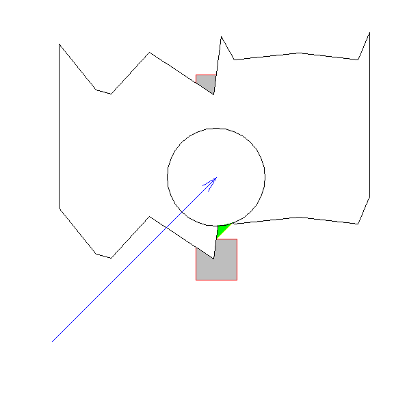

```r
pushViewport(plotViewport(margins = c(4, 4, 1, 1),
                          xscale = c(0, 4), yscale = c(0, 4)))
# drawing multiple rectangles in a single command
grid.rect(x = c(1, 2, 3, 2), y = c(2, 1, 2, 3), width = 0.5, height = 0.5,
          default.units = "native",
          gp = gpar(fill = "gray", col = "red"), draw = TRUE)
# drawing a polygon
grid.polygon(x = c(1.25, 2, 2.75, 2), y = c(2, 1.25, 2, 2.75),
             default.units = "native",
             gp = gpar(fill = "green", col = "yellow"), draw = TRUE)
# drawing a polygon with irregular shape
x <- sort(runif(10) * 4)
y <- runif(10) + 1
grid.polygon(x = c(x, rev(x)), y = c(y, rev(y) + 2),
             default.units = "native")
# drawing a circle
grid.circle(r = 0.15)
# drawing an arrow
grid.lines(x = c(0, 2), y = c(0, 2), default.units = "native",
           gp = gpar(col = "blue"),
           arrow = arrow(angle = 15, length = unit(0.2, units = "native"),
                         ends = "last"))
popViewport()
```

- `grid.lines` and `arrow`

Draws line segments. Can adjust line type, width and colour using parameter `gp`. Can also draw arrows by adding in the `arrow` parameter to coltrol the angle, length, type and position of the arrow head.

- `grid.rect`

Draws rectangles. Can adjust line type, width and colour of the outlines and filling colour using parameter `gp`

- `grid.points`

Draws points. Can adjust outline and filling colour using parameter `gp`. Adjustment of point shape is done with parameter `pch` instead of `gp`

- `grid.circle`

Draws circles. Can adjust line type, width and colour of the outlines and filling colour using parameter `gp`

- `grid.polygon`

Draws polygons by specifying the coordinates for every corner in an **anti-clockwise** order. Can adjust line type, width and colour of the outlines and filling colour using parameter `gp`

## Conventional Plots

### Scatter Plot

### Line Chart

### Confidence Interval

### Bar Chart

```r
#' Draws bar chart for given numerical variable.
#' @param height Vector of heights of bars. This is also twice the height of
#'   centres fo each bar.
#' @param x Vector of centre of bars. Defaults to be index of heights. With
#'   this parameter this function can also be used to make bar plots for
#'   multiple categories in the same plot.
#' @param width Width of each bar. Defaults to be \code{0.8}.
#' @param drawXaxis, drawYaxis Whether to draw X and Y axes. Default to be
#'   \code{TRUE}.
#' @param margins Margins for the resulting plot. Defaults to be no margin.
#' @param xscale X scale for the resulting plot. Defaults to be
#'   \code{c(0.5, length(x) + 0.5)}.
#' @param yscale Y scale for the resulting plot. Defaults to be
#'   \code{c(0, max(height, na.rm = TRUE))}.
#' @param ... Other parameters to pass to \code{gp} of \code{grid.rect}, e.g.
#'   colour for the bars and their outline.
#' @details Draws bar chart for given numerical variable. By default all values
#'   are taken to use native unit.
gridBarChart <- function(height, x = seq_along(height), width = 0.8,
                         drawXaxis = TRUE, drawYaxis = TRUE,
                         xNames = names(height),
                         margins = numeric(4),
                         xscale = c(0.5, length(x) + 0.5),
                         yscale = c(0, max(height, na.rm = TRUE)),
                         ...) {
  pushViewport(plotViewport(margins = margins, xscale = xscale,
                            yscale = yscale))
  for (i in seq_along(x)) {
    if (!is.na(height[i])) {
      grid.rect(x = x[i], y = height[i] / 2, width = width, height = height[i],
                default.units = "native", gp = gpar(...))
    }
  }
  if (drawXaxis) {
    if (is.null(xNames)) {
      xNames <- seq_along(height)
    }
    grid.xaxis(at = seq_along(height), label = xNames)
  }
  if (drawYaxis) {
    grid.yaxis()
  }
  popViewport()
}
```

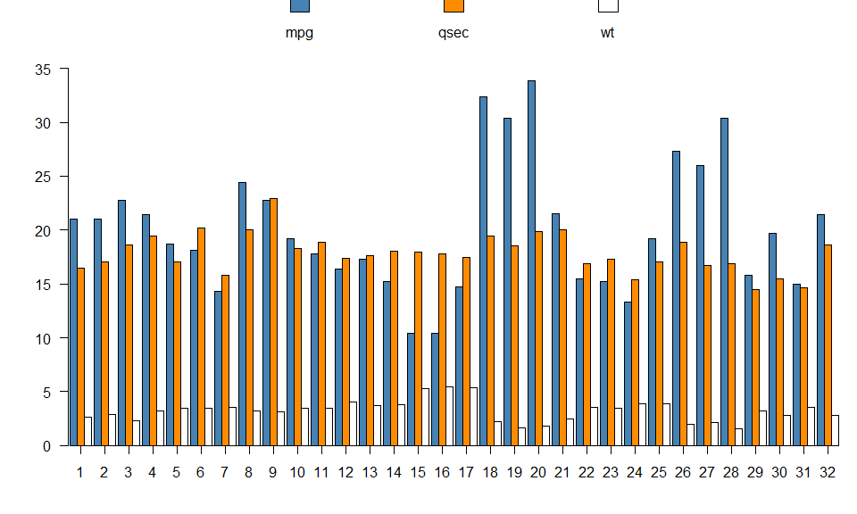

```r
yscale <- c(0, 35)
margins <- c(4, 4, 4, 1)
gridBarChart(height = mtcars$mpg, x = seq_along(mtcars$mpg) - 0.3,
             width = 0.3, margins = margins, yscale = yscale,
             fill = "steelblue")
gridBarChart(height = mtcars$qsec, x = seq_along(mtcars$qsec),
             width = 0.3, drawXaxis = FALSE, drawYaxis = FALSE,
             margins = margins, yscale = yscale,
             fill = "darkorange")
gridBarChart(height = mtcars$wt, x = seq_along(mtcars$wt) + 0.3,
             width = 0.3, drawXaxis = FALSE, drawYaxis = FALSE,
             margins = margins, yscale = yscale)
pushViewport(plotViewport(margins = margins))
grid.rect(x = 0.3, y = 1.2, width = 0.025, height = 0.1,
          gp = gpar(fill = "steelblue"))
grid.text(label = "mpg", x = 0.3, y = 1.1)
grid.rect(x = 0.5, y = 1.2, width = 0.025, height = 0.1,
          gp = gpar(fill = "darkorange"))
grid.text(label = "qsec", x = 0.5, y = 1.1)
grid.rect(x = 0.7, y = 1.2, width = 0.025, height = 0.1)
grid.text(label = "wt", x = 0.7, y = 1.1)
popViewport()
```

### Stacked Bar Plot

### Boxplot

### Heat Map

#### Set Colour

```r
#' Sets colour for a single value
#' @param value The value to set colour for.
#' @param breaks A list containing two named vectors, \code{neg} with breaks for
#'   the 'negative' values (i.e. values less than the perceived mid-point by
#'   user), and \code{pos} containing the breaks for 'positive' values. Do not
#'   include the  minimum or maximum. See \code{Details}.
#' @param colourRange A vector containing 3 colours. As values increase, the
#'   corresponding colour will change from \code{colourRange[1]} to
#'   \code{colourRange[2]} (at user-defined mid-point) and then to
#'   \code{colourRange[3]}. Default is \code{c("steelblue", "white",
#'   "darkorange")}. See \code{Details}.
#' @param special A list containing two components, \code{value} for the value
#'   to be assigned a unique colour to, and \code{colour} for the special
#'   colour. Currently only support a single \code{value} within \code{breaks}.
#'   Default is \code{NULL}.
#' @details The idea of including \code{special} as a parameter is to
#'   emphasise on a single value that is special in the context, e.g. 0 for
#'   change in variable or 0.5 for proportion. \code{breaks$neg} and
#'   \code{breaks$pos} are then meant for normal values smaller and larger
#'   than the special value. If there is no special value, \code{breaks} can be
#'   specified as either a vector or a list.
#'   Bourder values: \code{(-Inf, c1)[c1 , c2)...[c[n - 1] , cn)[cn, Inf)}.
#' @return Returns a vector of colours corresponding to values given, or a
#'   vector of colours corresponding to the given colour breaks if no value is
#'   specified.
setColour <- function(values = NULL, breaks,
                      colourRange = c("steelblue", "white", "darkorange"),
                      special = NULL) {
  # Function to find out the colours corresponding to values
  f <- function(v, breaks, colourVec) {
    # Return NA for NA
    if (is.na(v)) {
      return(NA)
    }
    # Find out breaks less than or equal to v
    brks <- breaks[breaks <= v]
    # If there is no such breaks, v is less than minimum
    if (length(brks) == 0) {
      return(colourVec[1])
    }
    # Else, find out the interval containing v
    l <- which(breaks == brks[1]) + 1
    # Return the colour corresponding to that interval
    return(colourVec[l])
  }
  if (is.null(special)) {
    # When there is no special value to consider, breaks can be a vector
    breaks <- sort(unlist(breaks))
    len <- length(breaks)
    if (len == 0) {
      stop(simpleError("Please specify breaks for values."))
    }
    if ((len %% 2) == 0) {
      l <- len / 2
      colourVec <- c(
        colorRampPalette(c(colourRange[1], colourRange[2]))(l + 1)[1:l],
        colourRange[2],
        colorRampPalette(c(colourRange[2], colourRange[3]))(l + 1)[-1]
      )
    } else {
      l <- (len + 1) / 2
      colourVec <- c(
        colorRampPalette(c(colourRange[1], colourRange[2]))(l + 1)[1:l],
        colorRampPalette(c(colourRange[2], colourRange[3]))(l + 1)[-1]
      )
    }
    if (is.null(values)) {
      return(colourVec)
    }
    sapply(values, function(v) f(v, breaks, colourVec))
  } else {
    # breaks$neg should only contain values less than special$value, and
    # breaks$pos should only contain values greater than special$value.
    breaks$neg <- breaks$neg[which(breaks$neg < special$value)]
    breaks$pos <- breaks$pos[which(breaks$pos > special$value)]
    # When there is special value, breaks must be a list. One of the components
    # in breaks can be empty, but cannot be both.
    if (length(unlist(breaks)) == 0) {
      stop(simpleError(
        paste("When there is special value, breaks must be a list.",
              "One of the components in breaks can be empty,",
              "but cannot be both.")
      ))
    }
    len1 <- length(breaks$neg)
    len2 <- length(breaks$pos)
    if ((len1 != 0) | (len2 != 0)) {
      colourVec1 <- colorRampPalette(c(colourRange[1],
                                       colourRange[2]))(len1 + 2)[1:(len1 + 1)]
      colourVec2 <- colorRampPalette(c(colourRange[2],
                                       colourRange[3]))(len2 + 2)[-1]
      # If values are not specified, return the vector of colours, including
      # the colour for special value.
      if (is.null(values)) {
        return(c(colourVec1, special$colour, colourVec2))
      }
      sapply(values,
             function(v) {
               if (is.na(v)) {
                 NA
               } else if (v == special$value) {
                 special$colour
               } else if (v < special$value) {
                 f(v, breaks$neg, colourVec1)
               } else {
                 f(v, breaks$pos, colourVec2)
               }
             })
    } else if (len2 == 0) {
      # If one of the components in breaks is empty, the problem reduces to the
      # case above.
      colourVec1 <- colorRampPalette(c(colourRange[1],
                                       colourRange[2]))(len1 + 2)[1:(len1 + 1)]
      if (is.null(values)) {
        return(c(colourVec1, special$colour))
      }
      sapply(values, function(v) f(v, breaks$neg, colourVec1))
    } else {
      colourVec2 <- colorRampPalette(c(colourRange[2],
                                       colourRange[3]))(len2 + 2)[-1]
      if (is.null(values)) {
        return(c(special$colour, colourVec2))
      }
      sapply(values, function(v) f(v, breaks$pos, colourVec2))
    }
  }
}
```

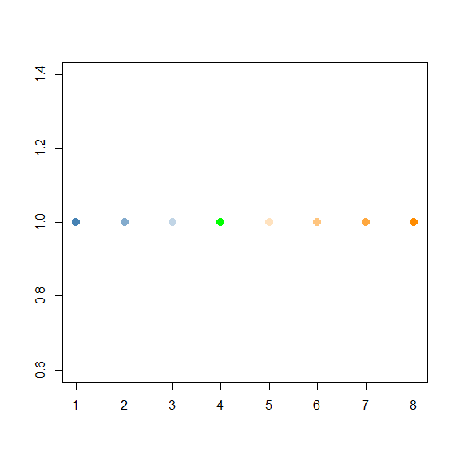

```r
cols <- setColour(breaks = list(neg = c(-2, -1), pos = c(1, 2, 3)),
                  special = list(value = 0, colour = "green"))
plot(x = seq_along(cols), y = rep(1, length(cols)), pch = 20, cex = 2,
     col = cols, xlab = "", ylab = "")
```

```r
#' Draw a heatmap given the color of each rectangle
#' @param colorMat A matrix of colors.
#' @param colNames Names of each column.
#' @param gap Width of white gap between rectangles so as to distinguish them.
#'   Default value is 0.01 (native).
#' @param margine Margin when pushing viewport within the function.
drawHeatmap <- function(colorMat, colNames = NULL, gap = 0.01,
                        margin = c(4, 0, 0, 1)) {
  # Make the colorMat upside down so that the first day is on the top. Also
  # revert noDataLIS and noDataIHIS.
  colorMat <- colorMat[nrow(colorMat):1, ]
  if (is.null(colNames)) {
    colNames <- colnames(colorMat)
  } else if ((length(colNames) != ncol(colorMat))) {
    stop(simpleError(
      "Please make sure length of column names is equal to numbr of columns of
      color matrix."))
  }
  pushViewport(plotViewport(margins = margin,
                            xscale = c(0.5, ncol(colorMat) + 0.5),
                            yscale = c(0.5, nrow(colorMat) + 0.5)))
  for (i in 1:nrow(colorMat)) {
    for (j in 1:ncol(colorMat)) {
      grid.rect(x = j, y = i, width = 1 - gap, height = 1 - gap,
                default.units = "native",
                gp = gpar(fill = colorMat[i, j], col = NA))
    }
  }
  # Column names
  grid.text(label = colNames, x = unit(1:ncol(colorMat), "native"),
            y = unit(0, "lines"), just = "top", gp = gpar(cex = 3))
  popViewport()
}
```

```r
valueMat <- matrix(rnorm(20 * 30), ncol = 20)
```

## Unconventional Plots

### Broken Axis

Adds a break on y axis. For this to work properly, the y value in the data needs to be adjusted accordingly.

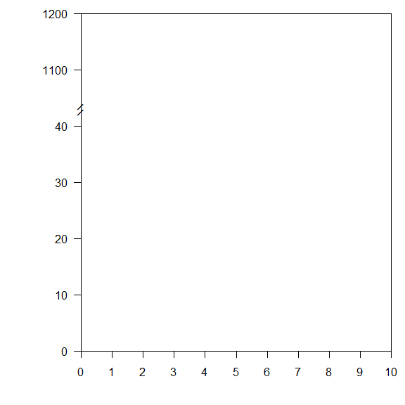

```r
pushViewport(plotViewport(c(4, 6, 1, 1), xscale = c(0, 10), yscale = c(0, 60)))
  grid.rect()
  grid.xaxis(at = seq(0, 10, 1), label = seq(0, 10, 1))
  grid.yaxis(at = seq(0, 60, 10), label = c(seq(0, 40, 10), 1100, 1200))
  grid.text("l", x = 0, y = 42.5, rot = -45, default.units = "native")
  grid.text("l", x = 0, y = 43.5, rot = -45, default.units = "native")
popViewport()
```

### Bars for Time Periods

```r
#' Draws coloured blocks to visualise time periods.
#' @param periods A data.frame containing the starting and ending points of the
#'   time periods, with column names \code{start} and \code{end} respectively.
#'   All time points must be of type \code{POSIXct}.
#' @param timeOrigin Time origin chosen for the visualisation. Defaults to be
#'   \code{NULL}, in which case it will be \code{0:0:0} of the first day in
#'   the input time points.
#' @param margins Margins for the resulting plot. Defaults to be no margin.
#' @param xscale X scale when pushing viewport for the resulting plot. Defaults
#'   to start from \code{0:0:0} of the first day, and end at \code{0:0:0} of
#'   the day following the last day of the given time period. For example, if
#'   the given time period starts from \code{1970-01-01 12:11:23} and ends at
#'   \code{1970-01-12 23:33:46}, then \code{xscale = as.numeric(c(t1, t2))},
#'   where \code{t1} and \code{t2} are \code{POSIXct} variables for
#'   \code{1970-01-01 0:0:0} and \code{1970-01-13 0:0:0} respectively.
#' @param y Passed to function \code{grid.rect} to determine the position of
#'   the coloured blocks. Should be a unit object. Defaults to be
#'   \code{unit(0.5, "npc")}.
#' @param height Passed to function \code{grid.rect} to determine the height of
#'   the coloured blocks. Should be a unit object. Defaults to be
#'   \code{unit(1, "lines")}.
#' @param ... Other parameters to pass to \code{gp} of \code{grid.rect}, e.g.
#'   colour for the coloured blocks and their outline.
#' @param drawTimeAxis Determines whether to draw the time axis at the bottom
#'   of the resulting plot. Defaults to be \code{TRUE}. See \code{details}.
#' @details The resulting plot includes coloured block to represent given time
#'   periods, and if \code{drawTimeAxis} a time axis at the bottom of the plot
#'   (\code{y = unit(c(0, 0), "npc")}) to indicate the dates covered by the
#'   periods. Only dates are printed to the time axis except the first and last
#'   days, which also have abbreviated names of month.
gridTimePeriod <- function(periods, timeOrigin = NULL,
                           margins = numeric(4), xscale = NULL,
                           y = unit(0.5, "npc"), height = unit(1, "lines"),
                           drawTimeAxis = TRUE, ...) {
  # If timeOrigin is not specified, use the first day in the given time periods
  if (is.null(timeOrigin)) {
    timeOrigin <- as.POSIXct(strptime(format(periods$start[1],
                                             "%Y-%m-%d 0:0:0"),
                                      format = "%Y-%m-%d %H:%M:%S"))
  }
  if (is.null(xscale)) {
    dayLast <- as.POSIXct(strptime(format(periods$end[nrow(periods)],
                                          "%Y-%m-%d 0:0:0"),
                                   format = "%Y-%m-%d %H:%M:%S"))
    dayLast <- as.POSIXct(dayLast + as.difftime(1, units = "days"))
    xscale <- as.numeric(c(timeOrigin, dayLast))
  }
  pushViewport(plotViewport(margins = margins, xscale = xscale))
  # Draw coloured blocks for time periods
  for (i in 1:nrow(periods)) {
    row <- as.numeric(periods[i, ])
    grid.rect(x = unit(mean(row), units = "native"), y = y,
              width = unit(row[2] - row[1] + 1, units = "native"),
              height = height, gp = gpar(...))
  }
  # Draw time axis (with ticks for days)
  if (drawTimeAxis) {
    grid.lines(y = c(0, 0))
    days <- seq(from = timeOrigin, to = dayLast,
                by = as.difftime(1, units = "days"))
    grid.points(x = unit(days, "native"), y = numeric(length(days)), pch = "|")
    # Labels for days: only include month for the frist and last day
    dayLabels <- format(days, "%d")
    dayLabels[1] <- paste(dayLabels[1], format(days[1], "%b"))
    dayLabels[length(days)] <- paste(dayLabels[length(days)],
                                     format(days[length(days)], "%b"))
    grid.text(label = dayLabels, x = unit(days, "native"),
              y = unit(-1, "lines"))
  }
  popViewport()
}
```

```r
# Create data for plotting
timeOrigin <- as.POSIXct(strptime(x = "2016-01-01 0:0:0",
                                  format = "%Y-%m-%d %H:%M:%S"))
timePoints <- sort(timeOrigin +
                     as.difftime(rnorm(n = 10, mean = 36000, sd = 1800),
                     units = "mins"))
periods <- data.frame(start = timePoints[c(1, 3, 5, 7, 9)],
                      end = timePoints[c(2, 4, 6, 8, 10)])
kable(periods)
```

| start | end |
| --- | --- |
| 2016-01-24 03:09:35 | 2016-01-25 14:47:56 |
| 2016-01-25 15:03:43 | 2016-01-26 06:18:12 |
| 2016-01-26 07:14:19 | 2016-01-26 17:00:47 |
| 2016-01-26 21:15:20 | 2016-01-27 12:22:46 |
| 2016-01-27 14:01:08 | 2016-01-27 14:46:49 |

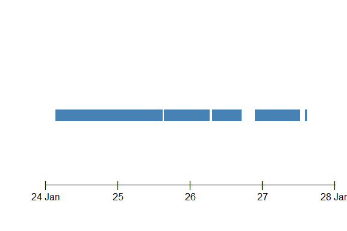

```r
gridTimePeriod(periods = periods, margins = c(4, 4, 4, 1),
               col = NA, fill = "steelblue")
```

# Saving Plot to File

## Dumping Plots to PDF

See file `try.pdf` for example of output.

```r
pdf("try.pdf")
for (i in 1:10) {
  grid.newpage()
  pushViewport(plotViewport(margins = c(4, 4, 1, 1)))
  grid.rect()
  grid.text(i, y = 0.6)
  grid.text(Sys.time(), y = 0.4)
  popViewport()
}
dev.off()
## png
##   2
```